# EDA Case Study

1. The credit amount of Loan purposes like 'Buying a home','Buying a land','Buying a new car' and'Building a house' is higher.
2. Income type of state servants have a significant amount of credit applied
3. Money for third person or a Hobby is having less credits applied for.

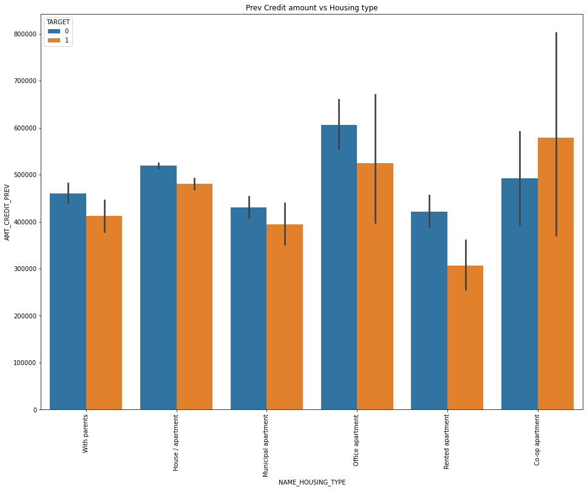

```python
# Box plotting for Credit amount prev vs Housing type in logarithmic scale

plt.figure(figsize=(16,12))
plt.xticks(rotation=90)
sns.barplot(data =new_df1, y='AMT_CREDIT_PREV',hue='TARGET',x='NAME_HOUSING_TYPE')
plt.title('Prev Credit amount vs Housing type')
plt.show()
```

- In Housing type, office appartment is having higher credit of target 0 and co-op apartment is having higher credit of target 1.
- We can conclude that bank should avoid giving loans to the housing type of co-op apartment as they are having difficulties in payment.
- Bank can focus mostly on housing type with parents or House\appartment or miuncipal appartment for successful payments.

# Summary

**From Univariate Analysis**

- variables with Maximum to minimum total counts of both the Target 0 and 1 are same. (Refer note in Univarite Analysis Section)
- Female Clients with Cash loans, No Car, Yes for Reality , Children count 0, working , Secondary / secondary special education, Married, Housing type House / apartment and Business Entity Type 3 are maximum in counts in the given dataset of application.

**From Bivariate Analysis**

- Most rejection of loans came from purpose 'repairs'.
- Clients which have applied for credits are from most of the organization type ‘Business entity Type 3’ , ‘Self employed’ , ‘Other’ , ‘Medicine’ and ‘Government’.
- Paying other loans and buying a new car is having significant higher rejection than approves.

**From Multivariate Analysis**

**From correlation plot with Target:**

- High Income people have less difficulty to pay
- High Credit people have less difficulty to pay
- More Populated Area clients ( Which can be one city clients ) have less diffulty to pay.
- Older employees(Days Employed) have less diffulty to pay the loans.

# CONCLUSION

1. ‘Student’ ,’pensioner’ and ‘Businessman’ with housing type other than ‘Co-op apartment’ are the contract types to be enrolled for successful payments.
2. Concentration should be more on clients from housing type ‘With parents’ as they are having least number of unsuccessful payments.
3. Clients with purpose ‘Repair’ is having higher number of unsuccessful payments on time.
4. Income type ‘Working’ should be on least priority, as they are having most number of unsuccessful payments.